# Pwani University Boot Camp

Author : Moses Kioko

Date : November 27, 2020

# 1 Work space set up

Prior to scripting in R, we removing the objects in R memory to pave way for a new objects, we do this by help of `rm()` function.

```r
#clear objects
rm(list = ls(all=T))
```

For easier access of files in directory and organized saving objects in R memory we need to change default computer directory to a folder that we can easily trace and access. We do this my help of `setwd()` function.

```r
#setting working directory

#set working directory
setwd('D:/pwani data collection/eric/MAWW/Workshop')

# print the current working directory
print(getwd())
```

```
## [1] "D:/pwani data collection/eric/MAWW/Workshop"
```

# 2 Packages

Installing packages can be done by downloading the packages from CRAN repository to R environment.*Please note; if you had prior installation of this packages you can skip re-installing them*

## 2.1 Installing Packages

- Installing packages from CRAN
  - install single package *i.e* `install.package("lubridate")`
  - install multiple packages by use of concatenator **c** *i,e* `install.packages(c('tidyverse','lubridate','forecast'))`
- Installing Packages from Github
  - install devtools package *i.e* `install.packages("devtools")`
  - load the library *i.e* `library(devtools)`
  - install the package *i.e* `devtools::install_github("tidyverse/lubridate")`

```r
#installing packages
#install.packages(c('tidyverse','lubridate','janitor','viridis','forecast'), dependencies = TRUE)
```

Attached is a brief description of the packages that will be used in this session

| Package | Description |
| --- | --- |
| Tidyverse Package | Manipulating data and plotting data [link](https://tidyverse.tidyverse.org/) |
| Lubridate package | Manipulating and changing date format [link](https://www.rdocumentation.org/packages/lubridate) |
| Janitor Package | Cleaning column names [link](https://www.rdocumentation.org/packages/janitor/versions/2.0.1) |
| Viridis Package | R color scale [link](https://www.rdocumentation.org/packages/viridis/versions/0.5.1) |
| Forecast Package | Handy in time-series [link](https://www.rdocumentation.org/packages/forecast/versions/8.13/topics/Arima) |

## 2.2 Loading Packages

To use the functions in a package you should load the package into R memory and you can do that by ;

- loading single package *i.e* `library()` command
- Load multiple packages *i.e* [pacman package](https://www.rdocumentation.org/packages/pacman/versions/0.5.1)

```r
#load libraries
library(tidyverse) # manipulating data, plotting package
library(lubridate) # changing date formats
library(janitor) # cleaning variable names
library(viridis) # coloring package
library(forecast) # for time series
```

# 3 Importing Data

Reading data into R memory using [readr package](https://www.rdocumentation.org/packages/readr/versions/1.3.1) housed in tidyverse package

```r
#import temperature data
temp <- read_delim('temperature.csv',';',trim_ws = TRUE) %>%
  clean_names()

#import precipitation data
precipitation <- read_delim('precipitation.csv', ';',trim_ws = TRUE) %>%
  clean_names()

#import MAWM data
yield <- read_delim('MAWW_data.csv',';',trim_ws = TRUE) %>%
  clean_names()
```

# 4 Exploring Data

## 4.1 Temperature Data

The are several steps that are involved to clean the temperature data ;

- Change the date format using lubricate package
- Calculate the year from date
- Summarize the mean temperature per year and site

```r
#summarizing data
temp_per_site <- temp %>%
  mutate(date = as_date(exceldate,origin ="1899-01-01")) %>%
  mutate(year = year(date)) %>%
  group_by(site,year) %>%
  summarise(mean_temp = mean(value))
```

To under understand general distribution of mean annual temperature we do a scatter plot.

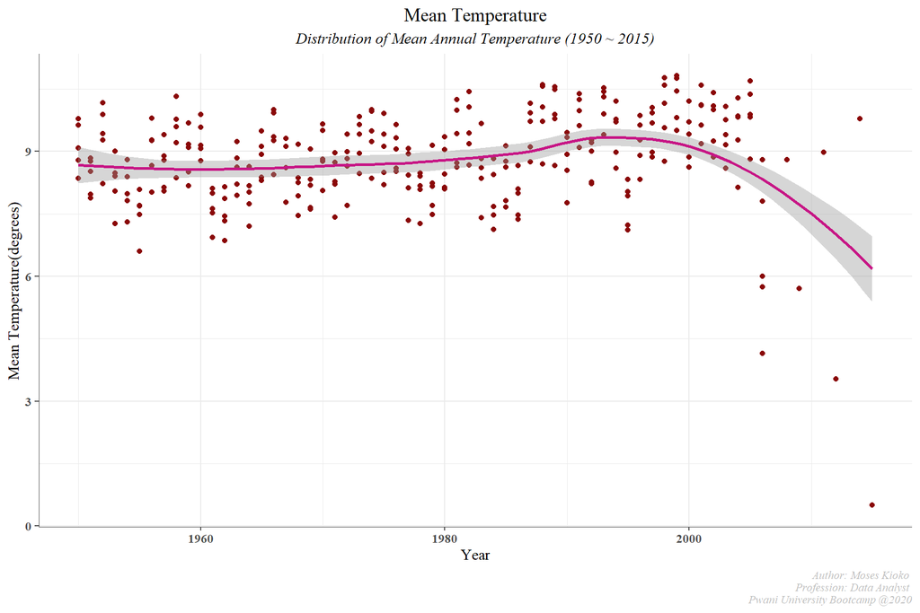

```r
#Single plot the data
temp_per_site %>%
  ggplot(aes(year,mean_temp))+
  geom_point(color ='#8A0707')+
  geom_smooth(stat = 'smooth',method = 'loess',color ='#c71585')+
  theme_minimal()+
  labs(title = "Mean Temperature",
       subtitle = "Distribution of Mean Annual Temperature (1950 ~ 2015)",
       y="Mean Temperature(degrees)",
       x="Year",
       caption = 'Author: Moses Kioko \n Profession: Data Analyst \n Pwani University Bootcamp @2020')+
  theme(legend.position = "bottom",
        legend.background = element_rect(color = "grey"),
        legend.title =  element_blank(),
        legend.text = element_text(family = "serif"),
        plot.title = element_text(hjust = 0.5,family = "serif"),
        axis.text = element_text(family = "serif", face = 'bold'),
        axis.title = element_text(family = "serif"),
        axis.line = element_line(colour = "grey30",size = .2),
        axis.ticks = element_line(colour = "grey30"),
        plot.subtitle = element_text(family = "serif",face = "italic",hjust = 0.5),
        plot.caption = element_text(size = 8,color = "grey",family = "serif",face = 'italic'))
```

The graph indicates a reduce in temperature from year 2000 which might not be the case due to presence of outliers that could be captured well in a box plot as indicated below. *Please note ;*

- We opt not to use liner model to reduce the error and show the trend in temperature
- The red square boxes helps fag the temperature outliers

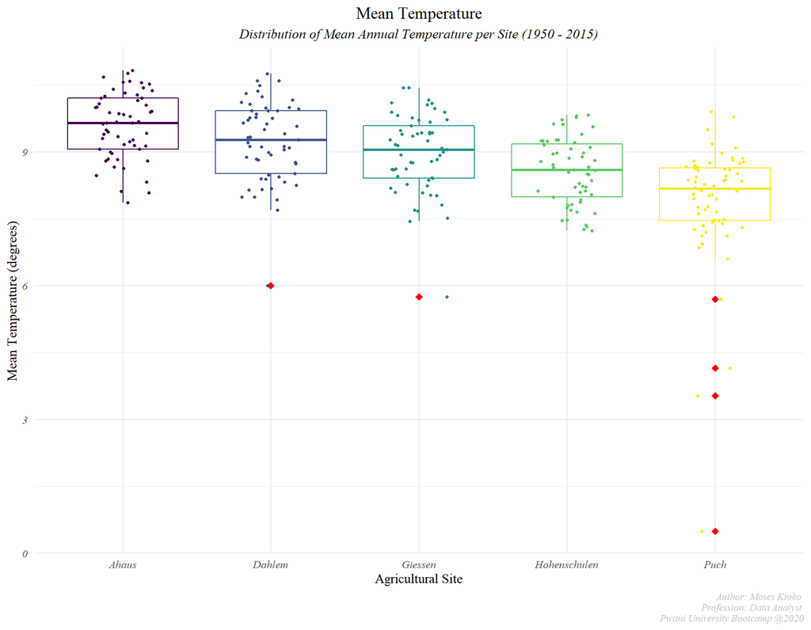

```r
#distribution of temperature per site
temp_per_site %>%
  ggplot(aes(site,mean_temp,color =site))+
  geom_boxplot(outlier.shape = 18,
               outlier.colour = "red",
               outlier.alpha = 1,
               outlier.size = 2.5)+
  geom_jitter(shape=16, position=position_jitter(0.2),cex=0.9)+
  scale_color_viridis_d()+
  theme_minimal()+
  labs(title = "Mean Temperature",
       subtitle = "Distribution of Mean Annual Temperature per Site (1950 - 2015)",
       y="Mean Temperature (degrees)",
       x="Agricultural Site",
       caption = 'Author: Moses Kioko \n Profession: Data Analyst \n Pwani University Bootcamp @2020')+
  theme(legend.position = "none",
        legend.background = element_rect(color = "grey"),
        legend.title =  element_blank(),
        legend.text = element_text(family = "serif"),
        plot.title = element_text(hjust = 0.5,family = "serif"),
        axis.text = element_text(family = "serif", face = 'italic'),
        axis.title = element_text(family = "serif"),
        plot.subtitle = element_text(family = "serif",face = "italic",hjust = 0.5),
        plot.caption = element_text(size = 8,color = "grey",family = "serif",face = 'italic'))
```

## 4.2 Precipitation Data

The following steps are used to tidy the precipitation data;

- Change the date format using lubricate package
- Calculate the year from date
- Summarize the mean precipitation per year and site

```r
#cleaning precipitation data by formatting date and calculating mean precipitation per year and site
precip_per_site <- precipitation %>%
  mutate(date = as_date(exceldate,origin ="1899-01-01")) %>%
  mutate(year = year(date)) %>%
  group_by(site,year) %>%
  summarise(mean_precip = mean(value)) %>%
  clean_names()
```

To understand distribution of mean annual distribution of precipitation in Germany we do a scatter plot and we add the trend over the years.

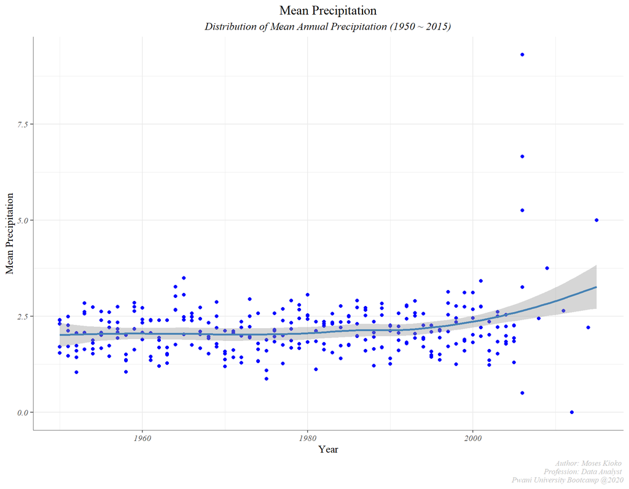

```r
#Single plot the data
precip_per_site %>%
  ggplot(aes(year,mean_precip))+
  geom_point(color ='blue')+
  geom_smooth(stat = 'smooth',method = 'loess',color ='steelblue')+
  theme_minimal()+
  labs(title = "Mean Precipitation",
       subtitle = "Distribution of Mean Annual Precipitation (1950 ~ 2015)",
       y="Mean Precipitation",
       x="Year",
       caption = 'Author: Moses Kioko \n Profession: Data Analyst \n Pwani University Bootcamp @2020')+
  theme(legend.position = "bottom",
        legend.background = element_rect(color = "grey"),
        legend.title =  element_blank(),
        legend.text = element_text(family = "serif"),
        plot.title = element_text(hjust = 0.5,family = "serif"),
        axis.text = element_text(family = "serif", face = 'italic'),
        axis.title = element_text(family = "serif"),
        axis.line = element_line(colour = "grey30",size = .2),
        axis.ticks = element_line(colour = "grey30"),
        plot.subtitle = element_text(family = "serif",face = "italic",hjust = 0.5),
        plot.caption = element_text(size = 8,color = "grey",family = "serif",face = 'italic'))
```

To have a closer distribution of mean annual precipitation we do a box plot. The box plot indicates presence of outliers, to flag this we have used red square points.

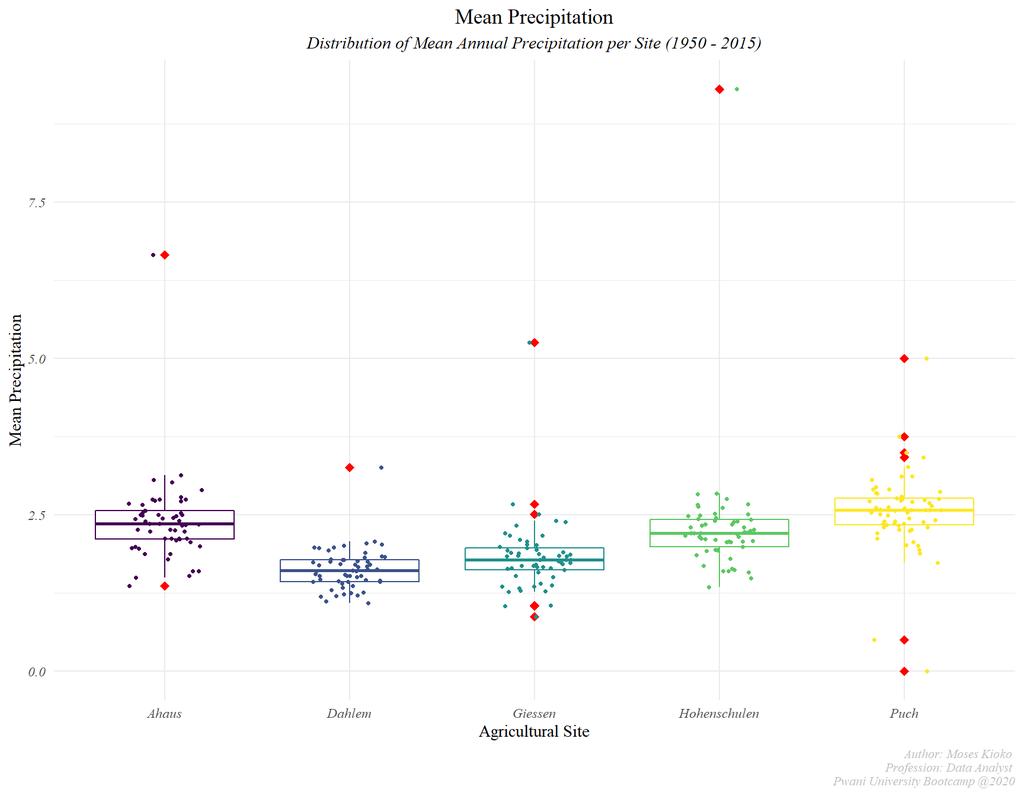

```r
#distribution of precipitation per site
precip_per_site %>%
  ggplot(aes(site,mean_precip,color =site))+
  geom_boxplot(outlier.shape = 18,
               outlier.colour = "red",
               outlier.alpha = 1,
               outlier.size = 2.5)+
  geom_jitter(shape=16, position=position_jitter(0.2),cex=0.9)+
  scale_color_viridis_d()+
  theme_minimal()+
  labs(title = "Mean Precipitation",
       subtitle = "Distribution of Mean Annual Precipitation per Site (1950 - 2015)",
       y="Mean Precipitation",
       x="Agricultural Site",
       caption = 'Author: Moses Kioko \n Profession: Data Analyst \n Pwani University Bootcamp @2020')+
  theme(legend.position = "none",
        legend.background = element_rect(color = "grey"),
        legend.title =  element_blank(),
        legend.text = element_text(family = "serif"),
        plot.title = element_text(hjust = 0.5,family = "serif"),
        axis.text = element_text(family = "serif", face = 'italic'),
        axis.title = element_text(family = "serif"),
        plot.subtitle = element_text(family = "serif",face = "italic",hjust = 0.5),
        plot.caption = element_text(size = 8,color = "grey",family = "serif",face = 'italic'))
```

# 5 Time Series

Time series is series of data points indexed at specific time. To better understand the trends of temperature and precipitation we take advantage of time-series which brings out the trends over time. We merge the temperature and precipitation data using dplyr function,`inner_join()`and we use year and site as unique keys in both of the data-sets.

```r
#merge precipitation and temperature data by year and site as unique key
precip_temp <- temp_per_site %>%
  inner_join(precip_per_site, by = c('year','site')) %>%
  #rename variable names
  rename(`Mean Temperature` = mean_temp,
         `Mean Precipitation` = mean_precip)
```

## 5.1 Time series Object

To convert temperature and precipitation into a time series object we make use of base R function `ts()`

```r
#converting to time series object
ts_object <- ts(precip_temp[,3:4], start = 1950, end = 2015,frequency = 6)
```

## 5.2 Visualize Time-series

To map the time series trends we plot the data by use of ggplot2 function, `autoplot()`

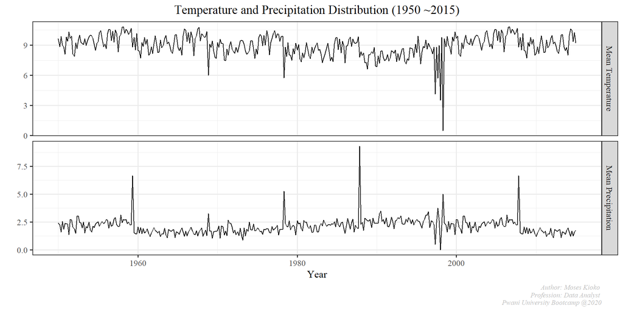

```r
#set the theme
theme_set(theme_bw(base_family = 'serif',
                   base_size = 12))
#plot the time series object
autoplot(ts_object,facets = TRUE)+
  labs(title = 'Temperature and Precipitation Distribution (1950 ~2015)',
       x = 'Year',
       y= '',
       caption = 'Author: Moses Kioko \n Profession: Data Analyst \n Pwani University Bootcamp @2020')+
  theme(plot.title = element_text(hjust = 0.5),
        plot.caption = element_text(size = 8,color = "grey",family = "serif",face = 'italic'))
```

## 5.3 Lag Calculation

lag is the difference of current years value and the former year. The attached equation better explains lag $lag_{t} = y_{t+1} - y_{t}$

```r
annual_precip_temp <- precip_temp %>%
  group_by(year) %>%
  summarise(annual_mean_temp = round(mean(`Mean Temperature`),2),
            annual_mean_prepcip = round(mean(`Mean Precipitation`),2)) %>%
  #compute for lag in both temp and precipitation
  mutate(`Temperature Lag` = annual_mean_temp - lag(annual_mean_temp)) %>%
  mutate(`Precipitation Lag` = annual_mean_prepcip - lag(annual_mean_prepcip))
```

Temperature and Precipitation lag plot. The plot as seasonal trend of increase in temperature or precipitation, this can inform the method of forecast we can use which would be seasonal naive method.

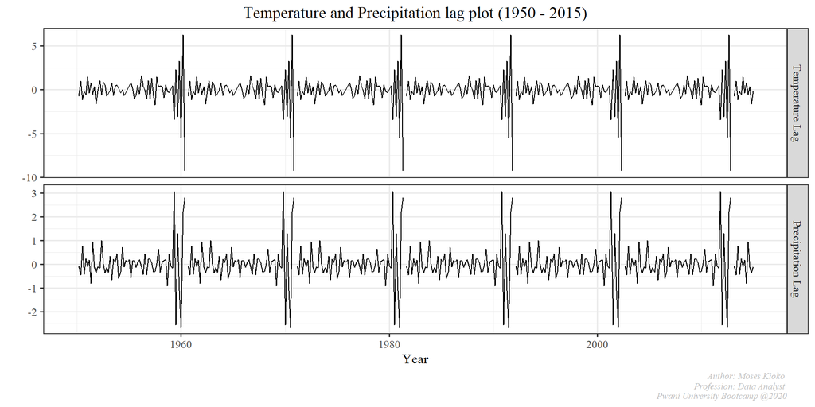

```r
#converting to time series object
lag_ts <- ts(annual_precip_temp[,4:5], start = 1950, end = 2015,frequency = 6)

#plot echo=TRUE, message=FALSE, warning=FALSE,fig.height=6,fig.width=10,fig.align='center'
autoplot(lag_ts,facets = TRUE)+
  labs(title = 'Temperature and Precipitation lag plot (1950 - 2015)',
       x = 'Year',
       y= '',
       caption = 'Author: Moses Kioko \n Profession: Data Analyst \n Pwani University Bootcamp @2020')+
  theme(plot.title = element_text(hjust = 0.5),
        plot.caption = element_text(size = 8,color = "grey",family = "serif",face = 'italic'))
```

## 5.4 Forecast

**Temperature Forecast**

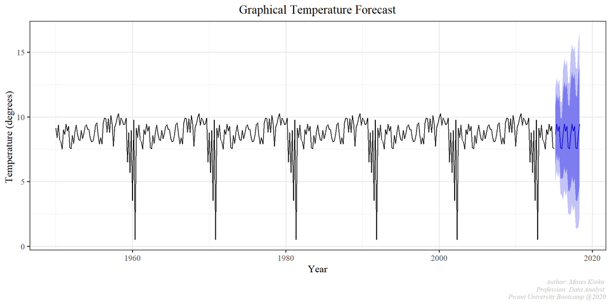

```r
temp_forecast <- ts(annual_precip_temp[,2],
                    start = 1950,
                    end = 2015,
                    frequency = 6)

# Forecasting
seasonal_naive <- snaive(temp_forecast, h = 20)

autoplot(temp_forecast)+
  autolayer(seasonal_naive)+
  labs(title = 'Graphical Temperature Forecast',
       x = 'Year',
       y= 'Temperature (degrees) ',
       caption = 'Author: Moses Kioko \n Profession: Data Analyst \n Pwani University Bootcamp @2020')+
  theme(plot.title = element_text(hjust = 0.5),
        plot.caption = element_text(size = 8,color = "grey",family = "serif",face = 'italic'))
```

**Precipitation Forecast**

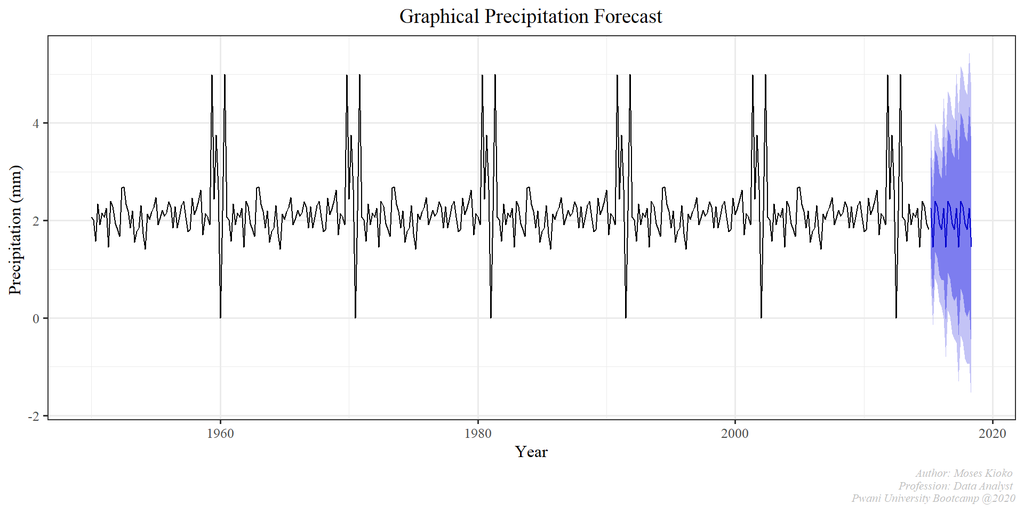

```r
#cover
prepcip_forecast <- ts(annual_precip_temp[,3],
                    start = 1950,
                    end = 2015,
                    frequency = 6)

# forecasting
seasonal_naive_prepcip <- snaive(prepcip_forecast, h = 20)

#plot
autoplot(prepcip_forecast)+
  autolayer(seasonal_naive_prepcip)+
  labs(title = 'Graphical Precipitation Forecast',
       x = 'Year',
       y= 'Precipitation (mm) ',
       caption = 'Author: Moses Kioko \n Profession: Data Analyst \n Pwani University Bootcamp @2020')+
  theme(plot.title = element_text(hjust = 0.5),
        plot.caption = element_text(size = 8,color = "grey",family = "serif",face = 'italic'))
```

## 5.5 Linear Model

Linear models help us to generation a mathematical equation to map a relationship between two or more variables. In our case we will find the relationship between temperature and precipitation.

$Temperature_{(degrees)} = 10.4023 - 0.8162Precipitation_{(mm)}$

```r
#convert to time series object
ts_series <- ts(annual_precip_temp[,2:3],start = 1950,end = 2015,frequency = 6)

#fit time-series linear model
linear_model <- forecast::tslm(annual_mean_temp~annual_mean_prepcip, data = ts_series)

#print the results
summary(linear_model)
```

```
##
## Call:
## forecast::tslm(formula = annual_mean_temp ~ annual_mean_prepcip,
##     data = ts_series)
##
## Residuals:
##     Min      1Q  Median      3Q     Max
## -6.8723 -0.3994  0.2692  0.7445  1.6961
##
## Coefficients:
##                     Estimate Std. Error t value Pr(>|t|)
## (Intercept)          10.4023     0.2380  43.702  < 2e-16 ***
## annual_mean_prepcip  -0.8162     0.1044  -7.818 5.09e-14 ***
## ---
## Signif. codes:  0 '***' 0.001 '**' 0.01 '*' 0.05 '.' 0.1 ' ' 1
##
## Residual standard error: 1.372 on 389 degrees of freedom
## Multiple R-squared:  0.1358, Adjusted R-squared:  0.1336
## F-statistic: 61.12 on 1 and 389 DF,  p-value: 5.094e-14
```

# 6 Modelling Yield Data

We are going to use linear model to model the wheat data, there fore a couple of packages are going to be helpful in this section

| Package | Description |
| --- | --- |
| GGally package | Plotting correlation table [link](https://www.rdocumentation.org/packages/GGally/versions/1.5.0) |
| MASS Package | helps selecting most important variables for the model [link](https://www.rdocumentation.org/packages/MASS/versions/7.3-53) |

```r
#install packages
#install.packages('moderndive',dependencies = T)
#install.packages('MASS',dependencies = T)
#install.packages('GGally',dependencies = T)

#load the packages
library(moderndive)
library(MASS)
library(GGally)
```

This section we; + Select the data we would want to include in our model + Rename the variables

```r
#rename variables
model_data <- yield %>%
  dplyr::select(yield = y_max,
                altitude = alt,
                fertilizer = n_fert,
                `soil quality` = sq,
                precipitation =map,
                temperature = mat,acwb)

#save model names
model_names <- names(model_data[,2:6])
```

Plotting correlation plot + Why correlation plot - Distribution of data points within a variable - Get the correlation coefficients that informs on whether to drop or maintain the variable + Helps avoid Auto correlation problem + Feature engineering *(i.e advanced topic of excluding highly related variables as they don not inform much on prediction)*

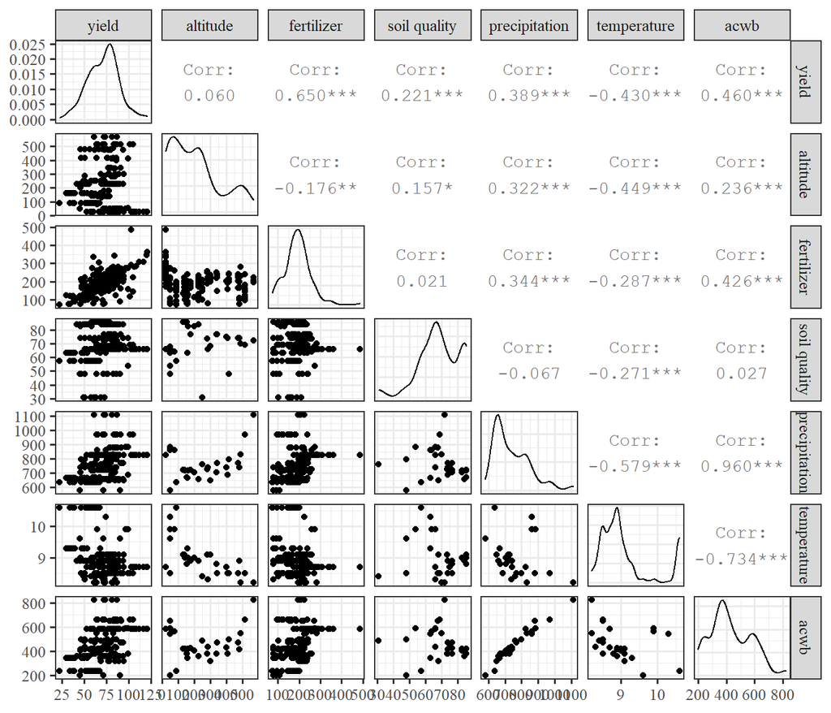

```r
#correlation plot
GGally::ggpairs(model_data)
```

Linear Regression Assumption + Normality of the y variable ..etc

To ensure we satisfy this requirement we do a density plot for wheat yield. please note ;

- Blue curve signifies the normal expected curve
- Grey curve indicates the actual distribution of wheat yield

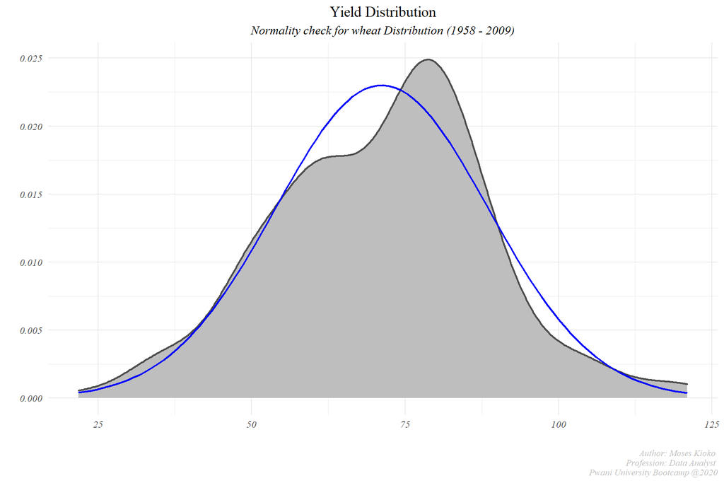

```r
model_data %>%
  ggplot(aes(yield))+
  #geom_histogram(bins = 20)+
  geom_density(size =.8,color ='grey30',fill ='grey')+
  stat_function(fun=dnorm,color="blue",size =.8,args=list(mean=mean(model_data$yield),
                                  sd=sd(model_data$yield)))+
  theme_minimal()+
  labs(title = "Yield Distribution",
       subtitle = "Normality check for wheat Distribution (1958 - 2009)",
       y="",
       x="",
       caption = 'Author: Moses Kioko \n Profession: Data Analyst \n Pwani University Bootcamp @2020')+
  theme(legend.position = "none",
        legend.background = element_rect(color = "grey"),
        legend.title =  element_blank(),
        legend.text = element_text(family = "serif"),
        plot.title = element_text(hjust = 0.5,family = "serif"),
        axis.text = element_text(family = "serif", face = 'italic'),
        axis.title = element_text(family = "serif"),
        plot.subtitle = element_text(family = "serif",face = "italic",hjust = 0.5),
        plot.caption = element_text(size = 8,color = "grey",family = "serif",face = 'italic'))
```

```r
#linear model
model = lm(yield ~ .,data=model_data)

#print out the summary of the model
moderndive::get_regression_table(model,print = T)
```

| term | estimate | std_error | statistic | p_value | lower_ci | upper_ci |
| --- | --- | --- | --- | --- | --- | --- |
| intercept | 66.578 | 27.534 | 2.418 | 0.016 | 12.322 | 120.834 |
| altitude | -0.018 | 0.014 | -1.253 | 0.211 | -0.046 | 0.010 |
| fertilizer | 0.178 | 0.016 | 10.892 | 0.000 | 0.146 | 0.210 |
| `soil quality` | 0.273 | 0.071 | 3.826 | 0.000 | 0.132 | 0.413 |
| precipitation | 0.168 | 0.088 | 1.913 | 0.057 | -0.005 | 0.342 |
| temperature | -12.054 | 5.363 | -2.247 | 0.026 | -22.622 | -1.486 |
| acwb | -0.138 | 0.080 | -1.720 | 0.087 | -0.297 | 0.020 |

```r
#compute the best model
best_model = MASS::stepAIC(model,direction = "both")
```

```
## Start:  AIC=1174.99
## yield ~ altitude + fertilizer + `soil quality` + precipitation +
##     temperature + acwb
##
##                  Df Sum of Sq   RSS    AIC
## - altitude        1     231.1 33647 1174.6
## <none>                        33416 1175.0
## - acwb            1     435.3 33852 1176.0
## - precipitation   1     539.0 33955 1176.7
## - temperature     1     743.6 34160 1178.1
## - `soil quality`  1    2155.2 35571 1187.6
## - fertilizer      1   17463.6 50880 1271.4
##
## Step:  AIC=1174.6
## yield ~ fertilizer + `soil quality` + precipitation + temperature +
##     acwb
##
##                  Df Sum of Sq   RSS    AIC
## - acwb            1     270.0 33917 1174.5
## <none>                        33647 1174.6
## + altitude        1     231.1 33416 1175.0
## - precipitation   1     487.5 34135 1176.0
## - temperature     1    1009.2 34657 1179.5
## - `soil quality`  1    1930.0 35577 1185.7
## - fertilizer      1   17316.3 50964 1269.8
##
## Step:  AIC=1174.47
## yield ~ fertilizer + `soil quality` + precipitation + temperature
##
##                  Df Sum of Sq   RSS    AIC
## <none>                        33917 1174.5
## + acwb            1     270.0 33647 1174.6
## + altitude        1      65.8 33852 1176.0
## - precipitation   1     590.2 34508 1176.5
## - temperature     1     891.8 34809 1178.5
## - `soil quality`  1    1855.0 35772 1184.9
## - fertilizer      1   19213.2 53131 1277.5
```

```r
#print out the summary of the model
moderndive::get_regression_table(best_model,print = T)
```

| term | estimate | std_error | statistic | p_value | lower_ci | upper_ci |
| --- | --- | --- | --- | --- | --- | --- |
| intercept | 41.049 | 20.891 | 1.965 | 0.051 | -0.115 | 82.213 |
| fertilizer | 0.167 | 0.015 | 11.390 | 0.000 | 0.138 | 0.196 |
| `soil quality` | 0.243 | 0.069 | 3.539 | 0.000 | 0.108 | 0.378 |
| precipitation | 0.019 | 0.010 | 1.996 | 0.047 | 0.000 | 0.038 |
| temperature | -3.603 | 1.468 | -2.454 | 0.015 | -6.496 | -0.710 |

The final model equation $Yield = 41.049 + 0.167Ferterlizer + 0.243SoilQuality + 0.019Precipitation - 3.603Temperature$

**Research more on;**

| Package | Description |
| --- | --- |
| moderndive Package | Helps generate multiple regression model table [link](https://moderndive.github.io/moderndive/) |